# HW01

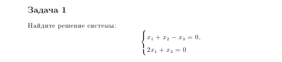

### Решение

Расширенная матрица: $$\left(\begin{array} {l c c | r} 1 & 1 & -1 & 0 \\ 2 & 0 & 1 & 0 \\ \end{array}\right)$$

Вычтем из второй строки две первых: $$\left(\begin{array} {l c c | r} 1 & 1 & -1 & 0 \\ 0 & -2 & 3 & 0 \\ \end{array}\right)$$

Разделим вторую строку на -2: $$\left(\begin{array} {l c c | r} 1 & 1 & -1 & 0 \\ 0 & 1 & -^3/_2 & 0 \\ \end{array}\right)$$

Вычтем из первой строки вторую: $$\left(\begin{array} {l c c | r} 1 & 0 & ^1/_2 & 0 \\ 0 & 1 & -^3/_2 & 0 \\ \end{array}\right)$$

#### Общее решение:

$$\begin{pmatrix} x_1 \\ x_2 \\ x_3 \end{pmatrix} = \begin{pmatrix} -^1/_2 \\ ^3/_2 \\ 1 \end{pmatrix} C_1 $$

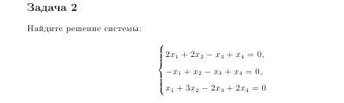

### Решение

Расширенная матрица: $$\left(\begin{array} {l c c c | r} 2 & 2 & -1 & 1 & 0 \\ -1 & 1 & -1 & 1 & 0 \\ 1 & 3 & -2 & 2 & 0 \end{array}\right)$$

Прибавим к первой строке вторую: $$\left(\begin{array} {l c c c | r} 1 & 3 & -2 & 2 & 0 \\ -1 & 1 & -1 & 1 & 0 \\ 1 & 3 & -2 & 2 & 0 \end{array}\right)$$

Первая и третья строка идентичны (линейно зависимы), следовательно, третью строку можно вычеркнуть: $$\left(\begin{array} {l c c c | r} 1 & 3 & -2 & 2 & 0 \\ -1 & 1 & -1 & 1 & 0 \end{array}\right)$$

Прибавим ко второй строке первую и разделим на 4: $$\left(\begin{array} {l c c c | r} 1 & 3 & -2 & 2 & 0 \\ 0 & 1 & -^3/_4 & ^3/_4 & 0 \end{array}\right)$$

Вычтем из первой строки вторую, умноженную на 3: $$\left(\begin{array} {l c c c | r} 1 & 0 & ^1/_4 & -^1/_4 & 0 \\ 0 & 1 & -^3/_4 & ^3/_4 & 0 \end{array}\right)$$

#### Общее решение:

$$\begin{pmatrix} x_1 \\ x_2 \\ x_3 \\ x_4 \end{pmatrix} = \begin{pmatrix} -^1/_4 & ^1/_4 \\ ^3/_4 & -^3/_4 \\ 1 & 0 \\ 0 & 1 \end{pmatrix} \begin{pmatrix} C_1 \\ C_2 \end{pmatrix} = \begin{pmatrix} -^1/_4 \\ ^3/_4 \\ 1 \\ 0 \end{pmatrix} C_1 + \begin{pmatrix} ^1/_4 \\ -^3/_4 \\ 0 \\ 1 \end{pmatrix} C_2 $$

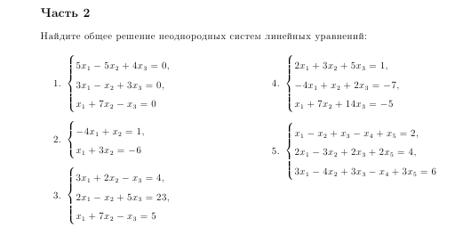

1. Расширенная матрица $$\left(\begin{array} {l c c | r} 5 & -5 & 4 & 0 \\ 3 & -1 & 3 & 0 \\ 1 & 7 & -1 & 0 \end{array}\right)$$

Разделим первую строку на 5: $$\left(\begin{array} {l c c | r} 1 & -1 & ^4/_5 & 0 \\ 3 & -1 & 3 & 0 \\ 1 & 7 & -1 & 0 \end{array}\right)$$

Вычтем из второй строки три первых строки: $$\left(\begin{array} {l c c | r} 1 & -1 & ^4/_5 & 0 \\ 0 & 2 & ^3/_5 & 0 \\ 1 & 7 & -1 & 0 \end{array}\right)$$

Вычтем из третьей строки первую: $$\left(\begin{array} {l c c | r} 1 & -1 & ^4/_5 & 0 \\ 0 & 2 & ^3/_5 & 0 \\ 0 & 8 & -^9/_5 & 0 \end{array}\right)$$

#### Общее решение:

$$\begin{pmatrix} x_1 \\ x_2 \\ x_3 \end{pmatrix} = \begin{pmatrix} 0 \\ 0 \\ 0 \end{pmatrix}$$

1. Расширенная матрица $$\left(\begin{array} {l c | r} -4 & 1 & 1 \\ 1 & 3 & -6 \end{array}\right)$$

Поменяем местами строки: $$\left(\begin{array} {l c | r} 1 & 3 & -6 \\ -4 & 1 & 1 \end{array}\right)$$

Прибавим ко второй строке четыре первых строки: $$\left(\begin{array} {l c | r} 1 & 3 & -6 \\ 0 & 13 & -23 \end{array}\right)$$

Разделим вторую строку на 13: $$\left(\begin{array} {l c | r} 1 & 3 & -6 \\ 0 & 1 & -^{23}/_{13} \end{array}\right)$$

Вычтем из первой строки три вторых строки: $$\left(\begin{array} {l c | r} 1 & 0 & -^9/_{13} \\ 0 & 1 & -^{23}/_{13} \end{array}\right)$$

#### Общее решение:

$$\begin{pmatrix} x_1 \\ x_2 \end{pmatrix} = \begin{pmatrix} -^9/_{13} \\ -^{23}/_{13} \end{pmatrix}$$

1. Расширенная матрица $$\left(\begin{array} {l c c | r} 3 & 2 & -1 & 4 \\ 2 & -1 & 5 & 23 \\ 1 & 7 & -1 & 5 \end{array}\right)$$

Вычтем из первой строки вторую: $$\left(\begin{array} {l c c | r} 1 & 3 & -6 & -19 \\ 2 & -1 & 5 & 23 \\ 1 & 7 & -1 & 5 \end{array}\right)$$

Вычтем из второй строки две третьих строки: $$\left(\begin{array} {l c c | r} 1 & 3 & -6 & -19 \\ 0 & -15 & 7 & 13 \\ 1 & 7 & -1 & 5 \end{array}\right)$$

Вычтем из третьей строки первую: $$\left(\begin{array} {l c c | r} 1 & 3 & -6 & -19 \\ 0 & -15 & 7 & 13 \\ 0 & 4 & 5 & 24 \end{array}\right)$$

Умножим третью строку на 3 и разделим на 4: $$\left(\begin{array} {l c c | r} 1 & 3 & -6 & -19 \\ 0 & -15 & 7 & 13 \\ 0 & 3 & ^{15}/_4 & 18 \end{array}\right)$$

Вычтем из первой строки третью: $$\left(\begin{array} {l c c | r} 1 & 0 & -^{39}/_4 & -37 \\ 0 & -15 & 7 & 13 \\ 0 & 3 & ^{15}/_4 & 18 \end{array}\right)$$

Умножим третью строку на 5: $$\left(\begin{array} {l c c | r} 1 & 0 & -^{39}/_4 & -37 \\ 0 & -15 & 7 & 13 \\ 0 & 15 & ^{75}/_4 & 90 \end{array}\right)$$

Прибавим к третьей строке вторую: $$\left(\begin{array} {l c c | r} 1 & 0 & -^{39}/_4 & -37 \\ 0 & -15 & 7 & 13 \\ 0 & 0 & ^{103}/_4 & 103 \end{array}\right)$$

Умножим третью строку на $^4/_{103}$: $$\left(\begin{array} {l c c | r} 1 & 0 & -^{39}/_4 & -37 \\ 0 & -15 & 7 & 13 \\ 0 & 0 & 1 & 4 \end{array}\right)$$

Прибавим к первой строке третью, умноженную на $^{39}/_4$

$$\left(\begin{array} {l c c | r} 1 & 0 & 0 & 2 \\ 0 & -15 & 7 & 13 \\ 0 & 0 & 1 & 4 \end{array}\right)$$

Разделим вторую строку на -15: $$\left(\begin{array} {l c c | r} 1 & 0 & 0 & 2 \\ 0 & 1 & -^7/_{15} & -^{13}/_{15} \\ 0 & 0 & 1 & 4 \end{array}\right)$$

Прибавим ко второй строке третью, умноженную на $^7/_{15}$ $$\left(\begin{array} {l c c | r} 1 & 0 & 0 & 2 \\ 0 & 1 & 0 & 1 \\ 0 & 0 & 1 & 4 \end{array}\right)$$

#### Общее решение:

$$\begin{pmatrix} x_1 \\ x_2 \\ x_3 \end{pmatrix} = \begin{pmatrix} 2 \\ 1 \\ 4 \end{pmatrix}$$

1. Расширенная матрица $$\left(\begin{array} {l c c | r} 2 & 3 & 5 & 1 \\ -4 & 1 & 2 & -7 \\ 1 & 7 & 14 & -5 \end{array}\right)$$

Вычтем из первой строки третью: $$\left(\begin{array} {l c c | r} 1 & -4 & -9 & 6 \\ -4 & 1 & 2 & -7 \\ 1 & 7 & 14 & -5 \end{array}\right)$$

Прибавим ко второй строке четыре первых строки: $$\left(\begin{array} {l c c | r} 1 & -4 & -9 & 6 \\ 0 & -15 & -34 & 17 \\ 1 & 7 & 14 & -5 \end{array}\right)$$

Вычтем из третьей строки первую: $$\left(\begin{array} {l c c | r} 1 & -4 & -9 & 6 \\ 0 & -15 & -34 & 17 \\ 0 & 11 & 23 & -11 \end{array}\right)$$

Вычтем из первой строки вторую и третью строку: $$\left(\begin{array} {l c c | r} 1 & 0 & 2 & 0 \\ 0 & -15 & -34 & 17 \\ 0 & 11 & 23 & -11 \end{array}\right)$$

Прибавим ко второй строке третью: $$\left(\begin{array} {l c c | r} 1 & 0 & 2 & 0 \\ 0 & -4 & -11 & 6 \\ 0 & 11 & 23 & -11 \end{array}\right)$$

Разделим вторую строку на -4: $$\left(\begin{array} {l c c | r} 1 & 0 & 2 & 0 \\ 0 & 1 & ^{11}/_4 & -^3/_2 \\ 0 & 11 & 23 & -11 \end{array}\right)$$

Вычтем из третьей строки одиннадцать вторых строк: $$\left(\begin{array} {l c c | r} 1 & 0 & 2 & 0 \\ 0 & 1 & ^{11}/_4 & -^3/_2 \\ 0 & 0 & -^{29}/_4 & ^{11}/_2 \end{array}\right)$$

Умножим третью строку на $-^4/_{29}$

$$\left(\begin{array} {l c c | r} 1 & 0 & 2 & 0 \\ 0 & 1 & ^{11}/_4 & -^3/_2 \\ 0 & 0 & 1 & -^{22}/_{29} \end{array}\right)$$

Вычтем из первой строки две третьих строки: $$\left(\begin{array} {l c c | r} 1 & 0 & 0 & ^{44}/_{29} \\ 0 & 1 & ^{11}/_4 & -^3/_2 \\ 0 & 0 & 1 & -^{22}/_{29} \end{array}\right)$$

Прибавим ко второй строке третью, умноженную на $-^{11}/_4$ $$\left(\begin{array} {l c c | r} 1 & 0 & 0 & ^{44}/_{29} \\ 0 & 1 & 0 & ^{17}/_{29} \\ 0 & 0 & 1 & -^{22}/_{29} \end{array}\right)$$

#### Общее решение:

$$\begin{pmatrix} x_1 \\ x_2 \\ x_3 \end{pmatrix} = \begin{pmatrix} ^{44}/_{29} \\ ^{17}/_{29} \\ -^{22}/_{29} \end{pmatrix}$$

1. Расширенная матрица $$\left(\begin{array} {l c c c c | r} 1 & -1 & 1 & -1 & 1 & 2 \\ 2 & -3 & 2 & 0 & 2 & 4 \\ 3 & -4 & 3 & -1 & 3 & 6 \end{array}\right)$$

Вычтем из второй строки две первых строки: $$\left(\begin{array} {l c c c c | r} 1 & -1 & 1 & -1 & 1 & 2 \\ 0 & -1 & 0 & 2 & 0 & 0 \\ 3 & -4 & 3 & -1 & 3 & 6 \end{array}\right)$$

Вычтем из третьей строки три первых строки: $$\left(\begin{array} {l c c c c | r} 1 & -1 & 1 & -1 & 1 & 2 \\ 0 & -1 & 0 & 2 & 0 & 0 \\ 0 & -1 & 0 & 2 & 0 & 0 \end{array}\right)$$

Вторая и третья строка идентичны (линейно зависимы), следовательно, третью строку можно вычеркнуть: $$\left(\begin{array} {l c c c c | r} 1 & -1 & 1 & -1 & 1 & 2 \\ 0 & -1 & 0 & 2 & 0 & 0 \end{array}\right)$$

Вычтем из первой строки вторую строку: $$\left(\begin{array} {l c c c c | r} 1 & 0 & 1 & -3 & 1 & 2 \\ 0 & -1 & 0 & 2 & 0 & 0 \end{array}\right)$$

Умножим вторую строку на -1: $$\left(\begin{array} {l c c c c | r} 1 & 0 & 1 & -3 & 1 & 2 \\ 0 & 1 & 0 & -2 & 0 & 0 \end{array}\right)$$

#### Общее решение:

$$\begin{pmatrix} x_1 \\ x_2 \\ x_3 \\ x_4 \\ x_5 \end{pmatrix} = \begin{pmatrix} 2 \\ 0 \\ 0 \\ 0 \\ 0 \end{pmatrix} + \begin{pmatrix} -1 & 3 & -1 \\ 0 & 2 & 0 \\ 1 & 0 & 0 \\ 0 & 1 & 0 \\ 0 & 0 & 1 \end{pmatrix} \begin{pmatrix} C_1 \\ C_2 \\ C_3 \end{pmatrix} = \begin{pmatrix} 2 \\ 0 \\ 0 \\ 0 \\ 0 \end{pmatrix} + \begin{pmatrix} -1 \\ 0 \\ 1 \\ 0 \\ 0 \end{pmatrix} C_1 + \begin{pmatrix} 3 \\ 2 \\ 0 \\ 1 \\ 0 \end{pmatrix} C_2 + \begin{pmatrix} -1 \\ 0 \\ 0 \\ 0 \\ 1 \end{pmatrix} C_3 $$